# Compito xx/01/2021

Emanuele Lena - 142411@uniud

10/2/2022

```r
knitr::knit('Funzioni2.Rmd')
```

```
##
##
## processing file: Funzioni2.Rmd
```

[output not shown]

[output cut: 25 more lines]

[output not shown]

```
## output file: Funzioni2.md
```

```
## [1] "Funzioni2.md"
```

```r
colest <- read.table("./data/colesterolo3.txt", header = T)
colest
```

[output not shown]

[output cut: 486 more lines]

Indice ~ Sesso + Eta + Trigliceridi

```r
colest2 <- colest[c("Indice", "Sesso", "Eta", "Trigliceridi")]
colest2$Sesso <- factor(colest$Sesso)

summary(colest2)
```

```
##      Indice      Sesso        Eta          Trigliceridi
##  Min.   :1.888   F:300   Min.   : 11.00   Min.   : 30.0
##  1st Qu.:2.749   M:200   1st Qu.: 49.00   1st Qu.: 76.0
##  Median :3.349           Median : 63.00   Median : 99.0
##  Mean   :3.509           Mean   : 60.93   Mean   :114.8
##  3rd Qu.:4.027           3rd Qu.: 73.25   3rd Qu.:134.0
##  Max.   :8.000           Max.   :103.00   Max.   :687.0
```

```r
nrow(colest2)
```

```
## [1] 500
```

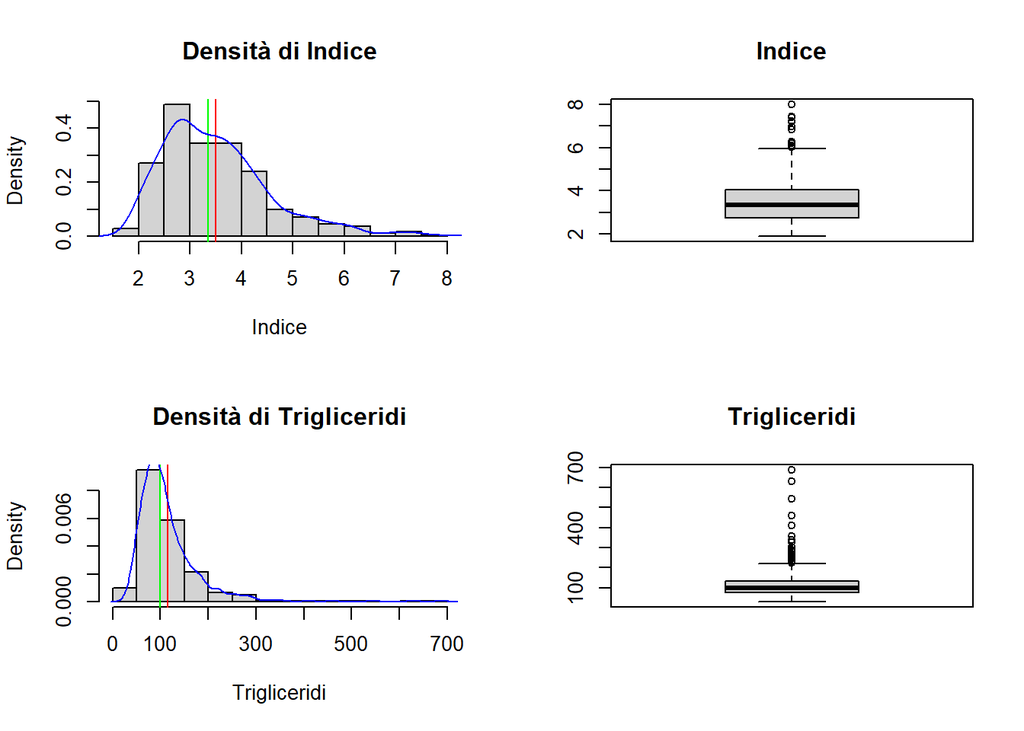

```r
par(mfrow=c(2,2))

gsummary.num("Indice", data=colest2)
gsummary.num("Trigliceridi", data=colest2)
```

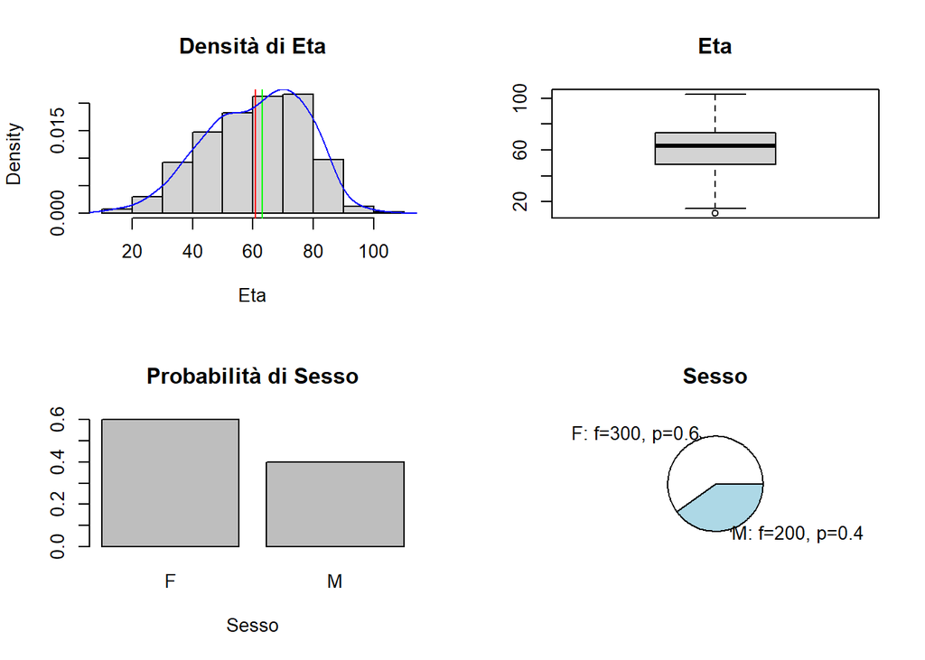

```r
gsummary.num("Eta", data=colest2)
gsummary.factor("Sesso", data=colest2)
```

```r
par(mfrow=c(1,1))
```

Le variabili risposta Indice e Trigliceridi sono caratt. da curve di densità a campana ma “spostate a sinistra”. In entrambi i casi si osserva assimetria e una coda destra costituita da numerose classificazioni indicate dai boxplot oltre il baffo del boxplot.

Anche età a suo modo è assimmetrica, con una coda più lunga ma a sinistra.

```r
par(mfrow=c(2,2))

gsummary.norm(colest2$Indice, stats = T, plots = c())
```

```
## [1] "NORMALITA' DI colest2$Indice"
##     Mean     Var.    Skew.    Kurt.
## 3.508828 1.111103 1.132874 4.621754
```

```r
gsummary.norm(colest2$Trigliceridi, stats = T, plots = c())
```

```
## [1] "NORMALITA' DI colest2$Trigliceridi"
##        Mean        Var.       Skew.       Kurt.
##  114.832000 4757.891559    3.438152   22.494687
```

```r
gsummary.norm(log(colest2$Indice), stats = T, plots = c("curve", "qq"))
```

```
## [1] "NORMALITA' DI log(colest2$Indice)"
##       Mean       Var.      Skew.      Kurt.
## 1.21424169 0.07986318 0.33163195 2.82460772
```

```
## [1] "NORMALITA' DI log(colest2$Trigliceridi)"
##      Mean      Var.     Skew.     Kurt.
## 4.6229651 0.2178699 0.5670996 3.9778823
```

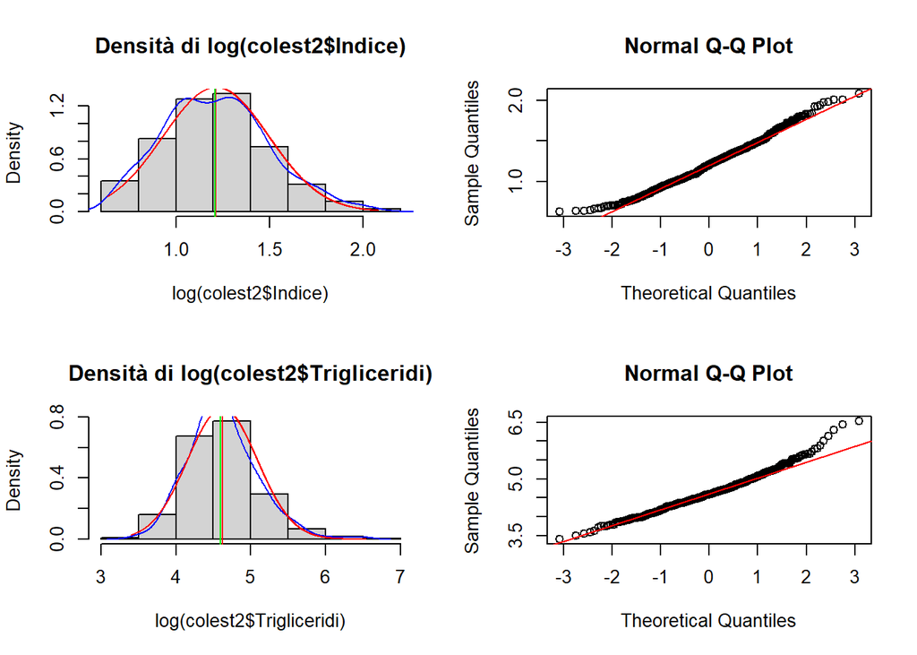

```r
gsummary.norm(log(colest2$Trigliceridi), stats = T, plots = c("curve", "qq"))
```

```r
# gsummary.norm(sqrt(colest2$Indice), stats = T, plots = c("curve", "qq"))
# gsummary.norm(sqrt(colest2$Trigliceridi), stats = T, plots = c("curve", "qq"))

par(mfrow=c(1,1))
```

Sia per Indice che per Trigliceridi si osserva come l’introduzione della scala logaritmica rende la curva più simile ad una normale (e “aggiusta” anche gli indici di assim. e curtosi)

```r
colest3 <- colest2[c("Eta","Sesso")]
colest3$logTrigliceridi <- log(colest2$Trigliceridi)
colest3$logIndice <- log(colest2$Indice)
```

### Correlazione tra variabili

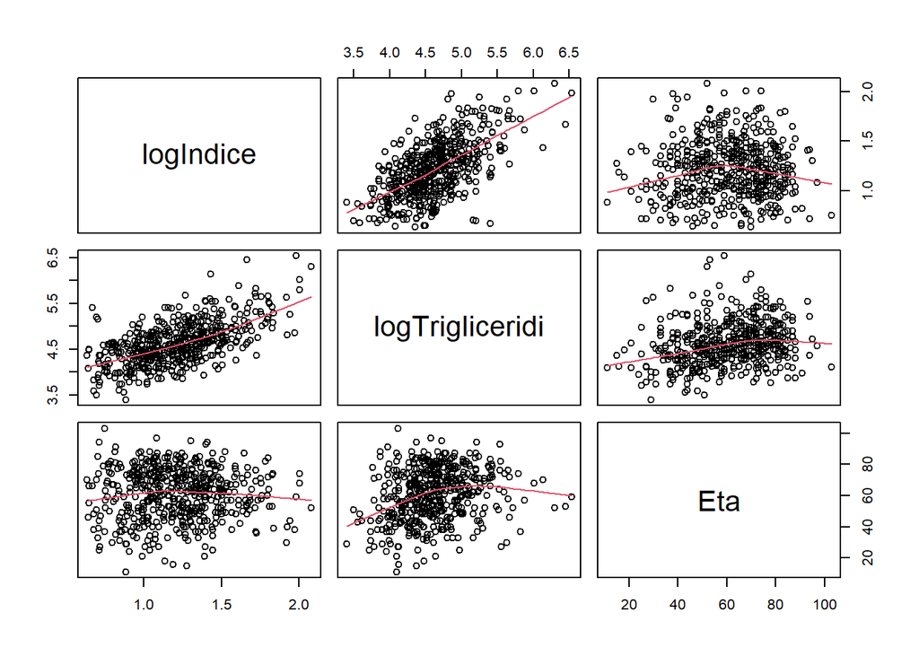

```r
pairs(colest3[c("logIndice", "logTrigliceridi", "Eta")], panel=panel.smooth)
```

```r
cor(colest3[c("logIndice", "logTrigliceridi", "Eta")], method = "pearson")
```

```
##                  logIndice logTrigliceridi        Eta
## logIndice       1.00000000       0.6103590 0.01458746
## logTrigliceridi 0.61035899       1.0000000 0.21940118
## Eta             0.01458746       0.2194012 1.00000000
```

```r
cor(colest3[c("logIndice", "logTrigliceridi", "Eta")], method = "spearman")
```

```
##                   logIndice logTrigliceridi         Eta
## logIndice       1.000000000       0.5816452 0.006815779
## logTrigliceridi 0.581645171       1.0000000 0.237745107
## Eta             0.006815779       0.2377451 1.000000000
```

Si osserva che logIndice presenta una correlazione (lineare) con logTrigliceridi. Eta invece sembra essere apparentemente meno influente.

```
## [1] "ANALISI PRELIMINARE DELLA CORRELAZIONE logIndice ~ Sesso"
## $F
##    Min. 1st Qu.  Median    Mean 3rd Qu.    Max.    Var. StdDev.   Skew.   Kurt.
## 0.63552 0.96472 1.11204 1.15018 1.33229 2.07944 0.07131 0.26704 0.61379 3.46012
##
## $M
##     Min.  1st Qu.   Median     Mean  3rd Qu.     Max.     Var.  StdDev.
##  0.65118  1.12051  1.30976  1.31033  1.49469  1.97981  0.07765  0.27866
##    Skew.    Kurt.
## -0.04966  2.76521
##
## $`<F,M>`
##
##  Welch Two Sample t-test
##
## data:  data[data[[groupname]] == lvls[i], varname] and data[data[[groupname]] == lvls[j], varname]
## t = -6.401, df = 413.98, p-value = 4.189e-10
## alternative hypothesis: true difference in means is not equal to 0
## 95 percent confidence interval:
##  -0.2093274 -0.1109668
## sample estimates:
## mean of x mean of y
##  1.150183  1.310330
```

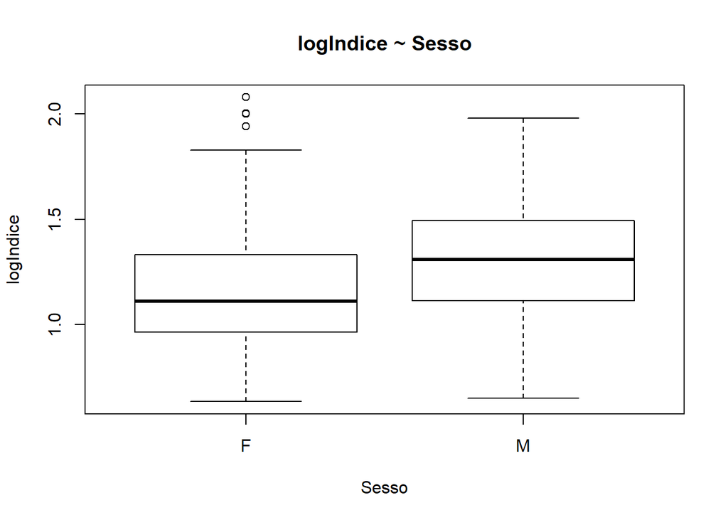

```r
cor.check.factor.num(xfactor = "Sesso", y="logIndice", data=colest3,
                     doPlot = T, doPlotLines = F, doMeanTest = T, doAnova = F, stats=T)
```

Il sesso - dai grafici e dal confronto tra medie camp. per gruppo - sembra essere significativo (con val inferiori per le donne).

### Modello lineare

Partiamo dalla definizione di un modello completo

```r
colest3.lm1 <- lm(logIndice~logTrigliceridi+Eta+Sesso, data=colest3)
summary(colest3.lm1)
```

```
##
## Call:
## lm(formula = logIndice ~ logTrigliceridi + Eta + Sesso, data = colest3)
##
## Residuals:
##      Min       1Q   Median       3Q      Max
## -0.88821 -0.13959 -0.00252  0.14915  0.56050
##
## Coefficients:
##                   Estimate Std. Error t value Pr(>|t|)
## (Intercept)     -0.4165021  0.0971940  -4.285 2.19e-05 ***
## logTrigliceridi  0.3688490  0.0213830  17.250  < 2e-16 ***
## Eta             -0.0019484  0.0006038  -3.227  0.00133 **
## SessoM           0.1106903  0.0198671   5.572 4.15e-08 ***
## ---
## Signif. codes:  0 '***' 0.001 '**' 0.01 '*' 0.05 '.' 0.1 ' ' 1
##
## Residual standard error: 0.2152 on 496 degrees of freedom
## Multiple R-squared:  0.4236, Adjusted R-squared:  0.4201
## F-statistic: 121.5 on 3 and 496 DF,  p-value: < 2.2e-16
```

Dal modello completo, si osserva che logTrigliceridi e il fattore Sesso risultano altamente significativi. Al contrario, Eta sembra essere meno rilevante, ma comunque significativo.

Dall’indice di determ. (e dalla sua v. corretta) si osserva che viene spiegata una quantità discreta di variabilità.

L’F-test infine indica che il modello - complessivamente - è esplicativo per i dati.

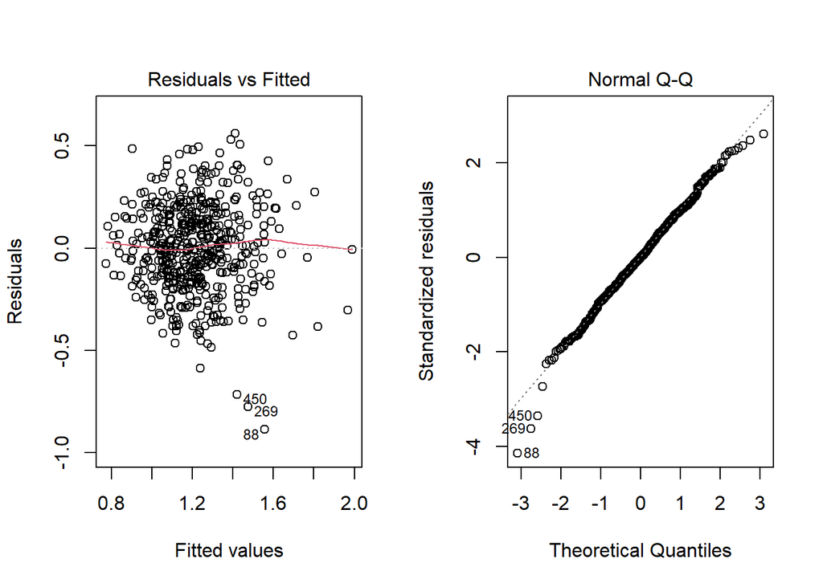

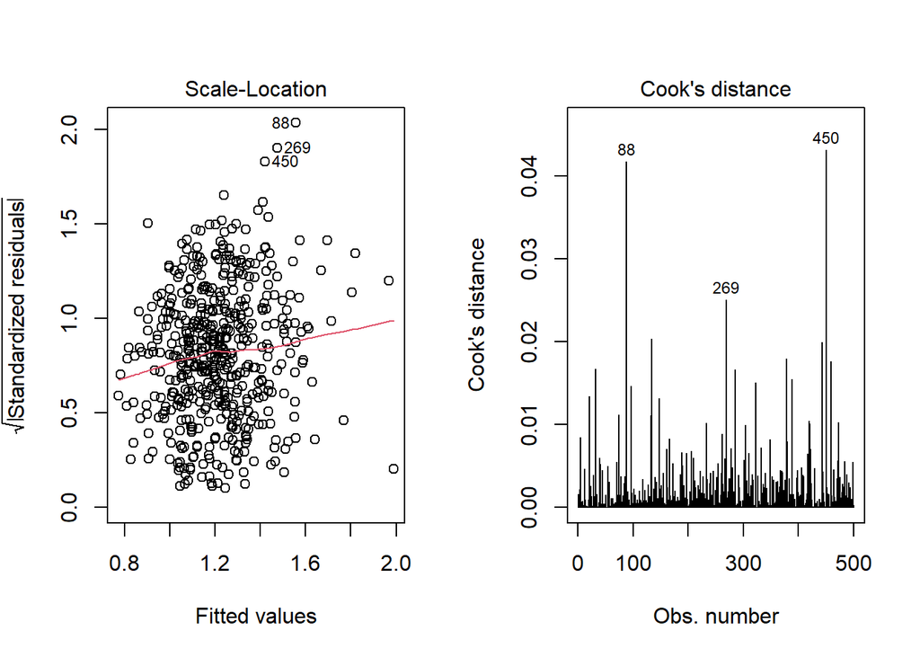

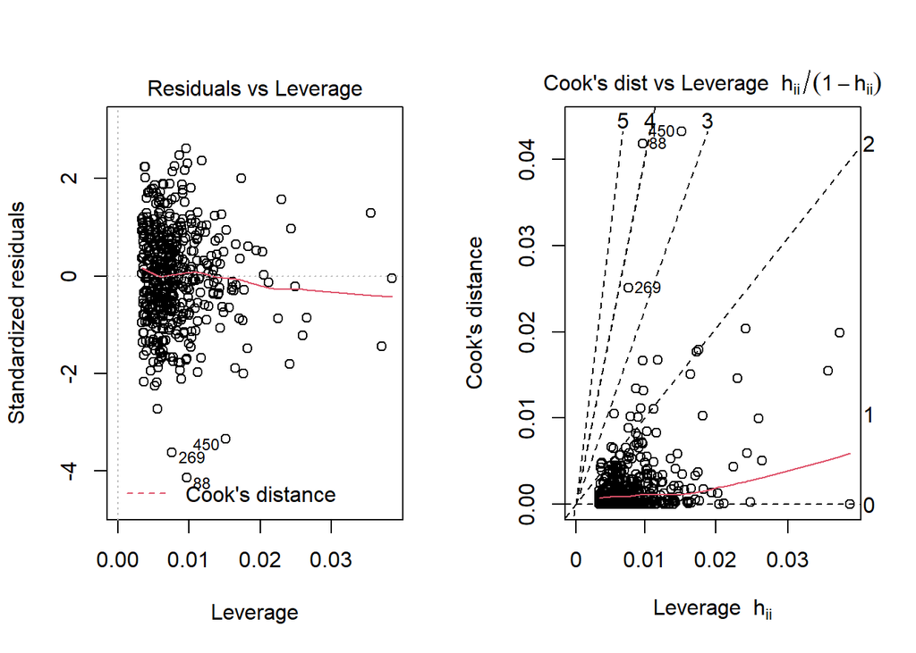

```r
par(mfrow=c(1,2))

plot(colest3.lm1, which=(1:6))
```

```r
par(mfrow=c(1,1))
```

Dalle diagnositche si nota che:

- a parte una concentrazione di oss. sui fitted values più bassi, non sembrano esserci pattern importanti sui residui;
- la variabilità dei residui aumenta leggermente per fitted values più alti
- i residui seguono una distribuzione abbastanza normale
- non ci sono osservazioni particolarmente influenti in senso assoluto

## Indagini per migliorie

Il modello creato sembra essere già esplicativo per i dati, detto ciò si vuole provare a valutarne qualche miglioramento.

Si prova ad indagare su eventuali effetti nati dall’iterazione tra Sesso e le variabili numeriche:

```r
par(mfrow=c(1,2))
cor.check.factor.num(xfactor = "Sesso", y="Eta", data=colest3,
                     doPlot = T, doPlotLines = F, doMeanTest = T, doAnova = F, stats=T)
```

```
## [1] "ANALISI PRELIMINARE DELLA CORRELAZIONE Eta ~ Sesso"
## $F
##     Min.  1st Qu.   Median     Mean  3rd Qu.     Max.     Var.  StdDev.
##  11.0000  50.0000  63.0000  61.3500  74.0000  97.0000 289.5928  17.0174
##    Skew.    Kurt.
##  -0.4618   2.5512
##
## $M
##      Min.   1st Qu.    Median      Mean   3rd Qu.      Max.      Var.   StdDev.
##  16.00000  49.00000  61.00000  60.29000  71.25000 103.00000 237.59387  15.41408
##     Skew.     Kurt.
##  -0.07879   2.63133
##
## $`<F,M>`
##
##  Welch Two Sample t-test
##
## data:  data[data[[groupname]] == lvls[i], varname] and data[data[[groupname]] == lvls[j], varname]
## t = 0.72236, df = 454.2, p-value = 0.4704
## alternative hypothesis: true difference in means is not equal to 0
## 95 percent confidence interval:
##  -1.823746  3.943746
## sample estimates:
## mean of x mean of y
##     61.35     60.29
```

```
## [1] "ANALISI PRELIMINARE DELLA CORRELAZIONE logTrigliceridi ~ Sesso"
## $F
##    Min. 1st Qu.  Median    Mean 3rd Qu.    Max.    Var. StdDev.   Skew.   Kurt.
##  3.4012  4.2905  4.5486  4.5716  4.8520  6.2989  0.2168  0.4656  0.4473  3.5730
##
## $M
##    Min. 1st Qu.  Median    Mean 3rd Qu.    Max.    Var. StdDev.   Skew.   Kurt.
##  3.7377  4.3789  4.6492  4.7001  4.9646  6.5323  0.2106  0.4589  0.8089  4.4901
##
## $`<F,M>`
##
##  Welch Two Sample t-test
##
## data:  data[data[[groupname]] == lvls[i], varname] and data[data[[groupname]] == lvls[j], varname]
## t = -3.049, df = 430.8, p-value = 0.002438
## alternative hypothesis: true difference in means is not equal to 0
## 95 percent confidence interval:
##  -0.21131032 -0.04565918
## sample estimates:
## mean of x mean of y
##  4.571571  4.700056
```

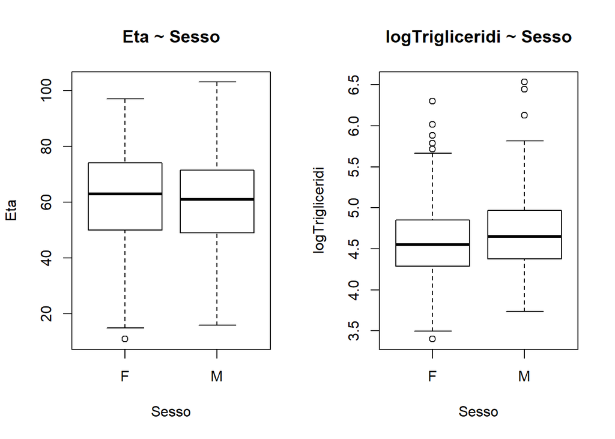

```r
cor.check.factor.num(xfactor = "Sesso", y="logTrigliceridi", data=colest3,
                     doPlot = T, doPlotLines = F, doMeanTest = T, doAnova = F, stats=T)
```

```r
par(mfrow=c(1,1))
```

Da questi confronti delle medie campionarie per gruppo e dai boxplot, non sembra esserci una correlazione tra sesso ed Eta, mentre il livello di logTrigliceridi per M sembra essere maggiore rispetto ad F.

```r
colest3.lm2 <- lm(logIndice~Eta+logTrigliceridi*Sesso, data = colest3)
summary(colest3.lm2)
```

```
##
## Call:
## lm(formula = logIndice ~ Eta + logTrigliceridi * Sesso, data = colest3)
##
## Residuals:
##      Min       1Q   Median       3Q      Max
## -0.86164 -0.13787  0.00077  0.14632  0.56503
##
## Coefficients:
##                          Estimate Std. Error t value Pr(>|t|)
## (Intercept)            -0.5266822  0.1230489  -4.280 2.24e-05 ***
## Eta                    -0.0020125  0.0006047  -3.328  0.00094 ***
## logTrigliceridi         0.3938097  0.0273778  14.384  < 2e-16 ***
## SessoM                  0.4000313  0.1995266   2.005  0.04552 *
## logTrigliceridi:SessoM -0.0622580  0.0427196  -1.457  0.14565
## ---
## Signif. codes:  0 '***' 0.001 '**' 0.01 '*' 0.05 '.' 0.1 ' ' 1
##
## Residual standard error: 0.215 on 495 degrees of freedom
## Multiple R-squared:  0.426,  Adjusted R-squared:  0.4214
## F-statistic: 91.86 on 4 and 495 DF,  p-value: < 2.2e-16
```

L’introduzione dell’effetto iterazione non sembra portare miglioramenti significativi al modello.

```r
anova(colest3.lm2)
```

```
## Analysis of Variance Table
##
## Response: logIndice
##                        Df  Sum Sq Mean Sq  F value    Pr(>F)
## Eta                     1  0.0085  0.0085   0.1835    0.6686
## logTrigliceridi         1 15.4339 15.4339 334.0025 < 2.2e-16 ***
## Sesso                   1  1.4377  1.4377  31.1125 4.012e-08 ***
## logTrigliceridi:Sesso   1  0.0981  0.0981   2.1239    0.1457
## Residuals             495 22.8735  0.0462
## ---
## Signif. codes:  0 '***' 0.001 '**' 0.01 '*' 0.05 '.' 0.1 ' ' 1
```

Ciò è evidende anche da un test di confronto della varianza.

### Previsione

Visto che non sembrano esserci necessità di effettuare miglioramenti al modello, indaghiamo sulla sua bontà predittiva.

Partiamo ricavando i due MSE sui dati di trainig e in cross validation.

```r
colest3.glm <- glm(logIndice~logTrigliceridi+Eta+Sesso, data=colest3)

glm.mse.train(colest3.glm)
```

```
## [1] 0.04594326
```

```r
glm.mse.test.cv(colest3.glm)
```

```
## [1] 0.04670399
```

Proviamo ad utilizzare il modello per ricavare alcuni intervalli di stima e di previsione, per diversi livelli di Trigliceridi, fissata un’età e un sesso.

```r
summary(colest2)
```

```
##      Indice      Sesso        Eta          Trigliceridi
##  Min.   :1.888   F:300   Min.   : 11.00   Min.   : 30.0
##  1st Qu.:2.749   M:200   1st Qu.: 49.00   1st Qu.: 76.0
##  Median :3.349           Median : 63.00   Median : 99.0
##  Mean   :3.509           Mean   : 60.93   Mean   :114.8
##  3rd Qu.:4.027           3rd Qu.: 73.25   3rd Qu.:134.0
##  Max.   :8.000           Max.   :103.00   Max.   :687.0
```

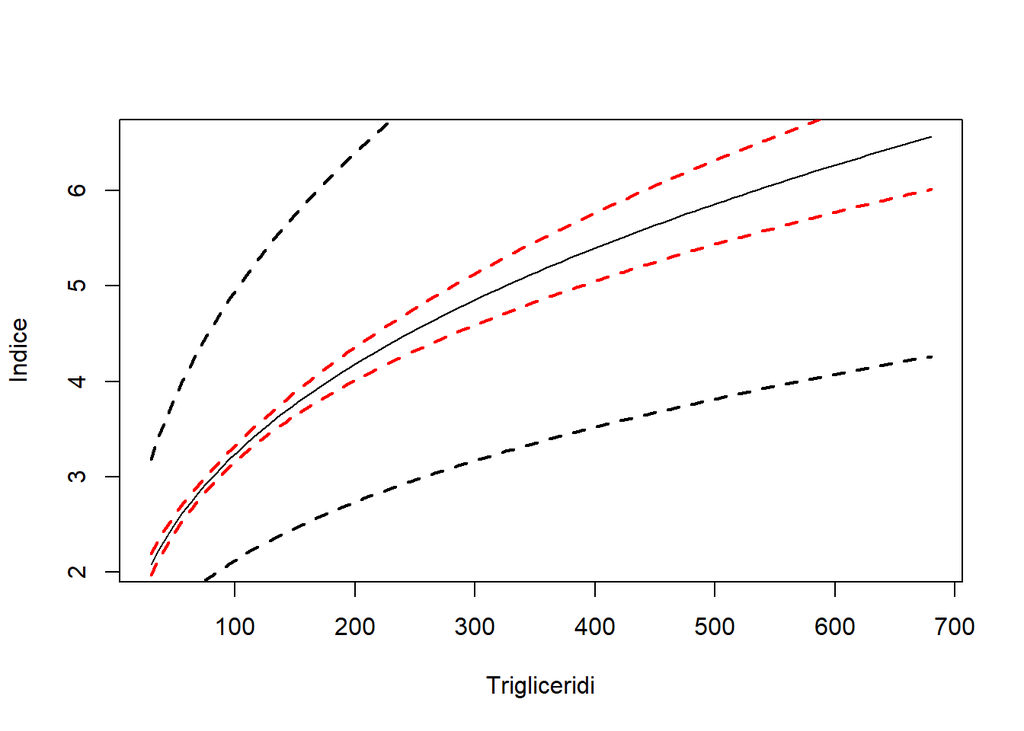

```r
# 100 oss, eta=55, sesso=F
test.data <- data.frame(
  Trigliceridi=seq(30, 680, length.out = 100),
  Eta=rep(55, 100),
  Sesso=rep("F", 100)
)

test.data$logTrigliceridi <- log(test.data$Trigliceridi)

stime <- predict(colest3.lm1, newdata=test.data, interval="confidence")
pred <- predict(colest3.lm1, newdata=test.data, interval="prediction")

# riporto in scala normale
stime2 <- exp(stime)
pred2 <- exp(pred)

plot(test.data$Trigliceridi, stime2[, "fit"], type="l", xlab = "Trigliceridi", ylab = "Indice")

lines(test.data$Trigliceridi, stime2[, "lwr"], lty = 2, lwd=2, col="red")
lines(test.data$Trigliceridi, stime2[, "upr"], lty = 2, lwd=2, col="red")

lines(test.data$Trigliceridi, pred2[, "lwr"], lty = 2, lwd=2, col="black")
lines(test.data$Trigliceridi, pred2[, "upr"], lty = 2, lwd=2, col="black")
```